# GEOG310, Lab 04, Time series analysis on AWS data

This notebook allows you to get more familiar with importing data from netcdf files (intorduced in Lab 03 last week). We will start by reviewing Lab 03 and then perfomring some time series analysis to undertsand te local weather conditions from the FENZ weatther station near Bottle Lake Forest north of Christchurch city.

**Useful notes from Lab 03**  
**What is the Xarray python library?** From https://docs.xarray.dev/en/stable/index.html  
"Xarray makes working with labelled multi-dimensional arrays in Python simple, efficient, and fun!"  
"Real-world datasets are usually more than just raw numbers; they have labels which encode information about how the array values map to locations in space, time, etc."

**Reading a netcdf file**

Netcdf (Network Common Data Form) file (*.nc) is a format that is widely used across scientific deciplines. It supports "the creation, access, and sharing of array-oriented scientific data" (https://www.unidata.ucar.edu/software/netcdf/).

**Matplotlib cheat sheet for plotting**  
https://matplotlib.org/cheatsheets/

# Section 01. Take 30mins to review Lab 03 (last week)

```python
# Spend 30mins going over and practicing Lab 03 (last week) concepts
```

```python
# Spend 30mins going over and practicing Lab 03 (last week) concepts
```

# Section 02

### Section 2.1. Importing Libraries and nectdf file dataset

```python
import xarray as xr
import numpy as np
import matplotlib.pyplot as plt
```

First, we need to use xarray to open/read the netcdf file. Using **open_dataset** function.

**TIP:** Another important function is **open_mfdataset** which can open multiple files and merge them automatically to a single dataset to use (more on that in upcoming labs)

Get the netcdf file from Learn Lab 03 folder and download it inot yoru working directory on see-trx4001 machine. The file name is called "FENZ_BLF_AWS_all.nc"

```python
ds = xr.open_dataset("./FENZ_BLF_AWS_all.nc")
```

The imported **dataset (ds)** has **data arrays** in it and are the fundamental data structures. Each **data array object** has dimensions associated with it sometimes more infromation known as **attributes**.

```python
ds # Exploring the xarray dataset, its dimensions, coordinates and data variables
```

```
<xarray.Dataset>
Dimensions:            (geometry: 1, height: 1, time: 235262)
Coordinates:
  * geometry           (geometry) object '0101000000AB9509BFD495654040FB91223...
  * height             (height) float32 2.0
  * time               (time) datetime64[ns] 1996-07-12T12:00:00 ... 2023-08-...
Data variables:
    externalId         (geometry) object '43.47028S 172.68222E V1.0'
    lat                (geometry) float64 -43.47
    lon                (geometry) float64 172.7
    name               (geometry) object 'Bottle Lake'
    ref                (geometry) object 'bottle_lake'
    station_id         (geometry) object '47feb204580757d31df499e7'
    wind_speed         (geometry, height, time) float32 ...
    wind_direction     (time, geometry, height) float32 ...
    temperature        (geometry, height, time) float32 ...
    precipitation      (time, geometry, height) float32 ...
    relative_humidity  (time, geometry, height) float32 ...
Attributes:
    result_type:     time_series
    title:           mean wind_speed in m/s of the atmosphere by a sensor_rec...
    institution:     FENZ
    license:         https://creativecommons.org/licenses/by/4.0/
    source:          sensor_recording
    system_version:  4
    version_date:    2022-03-23T00:00:00
```

### Section 2.3 Histograms

#### Task 01

```python
Tair=ds.sel(time=slice("2019-01-01","2023-01-01"))
ds_4years = Tair=ds.sel(time=slice("2019-01-01","2023-01-01"))
```

```python
print(ds_4years)
```

```
<xarray.Dataset>
Dimensions:            (geometry: 1, height: 1, time: 33007)
Coordinates:
  * geometry           (geometry) object '0101000000AB9509BFD495654040FB91223...
  * height             (height) float32 2.0
  * time               (time) datetime64[ns] 2019-01-01 ... 2023-01-01T23:00:00
Data variables:
    externalId         (geometry) object '43.47028S 172.68222E V1.0'
    lat                (geometry) float64 -43.47
    lon                (geometry) float64 172.7
    name               (geometry) object 'Bottle Lake'
    ref                (geometry) object 'bottle_lake'
    station_id         (geometry) object '47feb204580757d31df499e7'
    wind_speed         (geometry, height, time) float32 ...
    wind_direction     (time, geometry, height) float32 ...
    temperature        (geometry, height, time) float32 ...
    precipitation      (time, geometry, height) float32 ...
    relative_humidity  (time, geometry, height) float32 ...
Attributes:
    result_type:     time_series
    title:           mean wind_speed in m/s of the atmosphere by a sensor_rec...
    institution:     FENZ
    license:         https://creativecommons.org/licenses/by/4.0/
    source:          sensor_recording
    system_version:  4
    version_date:    2022-03-23T00:00:00
```

#### Task 02

Check that your time slice has worked by finding the following:

```
1. Size of the original ds dataset <br>
2. Size of the new time sliced ds_4years dataset <br>
3. Call the first and last time varaiable values for both datasets to make sure the time slicing worked <br>
```

```python
print(ds)
```

```
<xarray.Dataset>
Dimensions:            (geometry: 1, height: 1, time: 235262)
Coordinates:
  * geometry           (geometry) object '0101000000AB9509BFD495654040FB91223...
  * height             (height) float32 2.0
  * time               (time) datetime64[ns] 1996-07-12T12:00:00 ... 2023-08-...
Data variables:
    externalId         (geometry) object '43.47028S 172.68222E V1.0'
    lat                (geometry) float64 -43.47
    lon                (geometry) float64 172.7
    name               (geometry) object 'Bottle Lake'
    ref                (geometry) object 'bottle_lake'
    station_id         (geometry) object '47feb204580757d31df499e7'
    wind_speed         (geometry, height, time) float32 ...
    wind_direction     (time, geometry, height) float32 ...
    temperature        (geometry, height, time) float32 ...
    precipitation      (time, geometry, height) float32 ...
    relative_humidity  (time, geometry, height) float32 ...
Attributes:
    result_type:     time_series
    title:           mean wind_speed in m/s of the atmosphere by a sensor_rec...
    institution:     FENZ
    license:         https://creativecommons.org/licenses/by/4.0/
    source:          sensor_recording
    system_version:  4
    version_date:    2022-03-23T00:00:00
```

```python
print(ds_4years)
```

```
<xarray.Dataset>
Dimensions:            (geometry: 1, height: 1, time: 33007)
Coordinates:
  * geometry           (geometry) object '0101000000AB9509BFD495654040FB91223...
  * height             (height) float32 2.0
  * time               (time) datetime64[ns] 2019-01-01 ... 2023-01-01T23:00:00
Data variables:
    externalId         (geometry) object '43.47028S 172.68222E V1.0'
    lat                (geometry) float64 -43.47
    lon                (geometry) float64 172.7
    name               (geometry) object 'Bottle Lake'
    ref                (geometry) object 'bottle_lake'
    station_id         (geometry) object '47feb204580757d31df499e7'
    wind_speed         (geometry, height, time) float32 ...
    wind_direction     (time, geometry, height) float32 ...
    temperature        (geometry, height, time) float32 ...
    precipitation      (time, geometry, height) float32 ...
    relative_humidity  (time, geometry, height) float32 ...
Attributes:
    result_type:     time_series
    title:           mean wind_speed in m/s of the atmosphere by a sensor_rec...
    institution:     FENZ
    license:         https://creativecommons.org/licenses/by/4.0/
    source:          sensor_recording
    system_version:  4
    version_date:    2022-03-23T00:00:00
```

```python
first_time_Tair = Tair.time.values[0]
last_time_Tair = Tair.time.values[-1]
```

```python
print(first_time_Tair)
```

```
2019-01-01T00:00:00.000000000
```

```python
print(last_time_Tair)
```

```
2023-01-01T23:00:00.000000000
```

#### Task 03

Let's explore the distribution of the meteorlogical variables over these 4 years using the histogram function of matplotlib.

1. Explore and understand the matplotlib histogram function. You have imported the matplotlib library as plt. So use plt.hist? as a command for help or google "matplotlib histogram" https://matplotlib.org/stable/api/_as_gen/matplotlib.pyplot.hist.html
2. Plot the histogram for the meteorlogical variables  
   Air temperature  
   Wind speed  
   Wind direction  
   Relative humidity  
   Precipitation
3. Make your histogram look presentable and clearer by using x and y labels, titles, modify the number of bins, use edgecolor and facecolor, etc ...

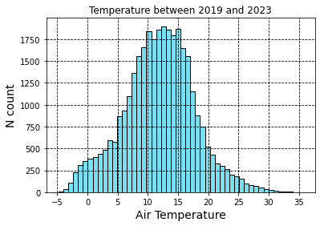

```python
#Air Temperature
plt.hist(ds_4years.temperature[0,0],bins=50,edgecolor="black",facecolor="#7bdff2")
#See colour code from this sample: https://coolors.co/palettes/trending
plt.grid(which="both", linestyle="dashed", color="black")
plt.xlabel("Air Temperature", fontsize=14)
plt.ylabel("N count", fontsize=14)
plt.title("Temperature between 2019 and 2023")
```

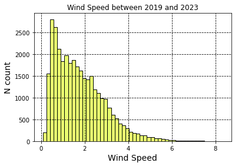

```python
#Wind Speed
plt.hist(ds_4years.wind_speed[0,0],bins=50,edgecolor="black",facecolor="#e9ff70")
#See colour code from this sample: https://coolors.co/palettes/trending
plt.grid(which="both", linestyle="dashed", color="black")
plt.xlabel("Wind Speed", fontsize=14)
plt.ylabel("N count", fontsize=14)
plt.title("Wind Speed between 2019 and 2023")
```

[figure not shown]

```python
#Relative Humidity
plt.hist(ds_4years.relative_humidity[0,0],bins=50,edgecolor="black",facecolor="#da627d")
#See colour code from this sample: https://coolors.co/palettes/trending
plt.grid(which="both", linestyle="dashed", color="black")
plt.xlabel("Relative Humidity", fontsize=14)
plt.ylabel("N count", fontsize=14)
plt.title("Relative Humidity between 2019 and 2023")
```

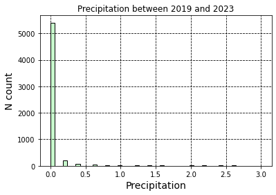

```python
#Precipitation
plt.hist(ds_4years.precipitation[:,0,0],bins=50,edgecolor="black",facecolor="#c7f9cc",range=(0,3))
#See colour code from this sample: https://coolors.co/palettes/trending
plt.grid(which="both", linestyle="dashed", color="black")
plt.xlabel("Precipitation", fontsize=14)
plt.ylabel("N count", fontsize=14)
plt.title("Precipitation between 2019 and 2023")
```

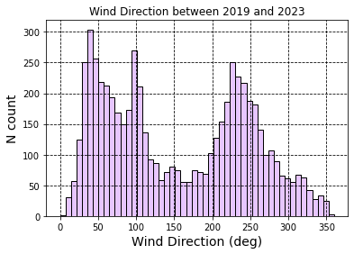

```python
#Precipitation
plt.hist(ds_4years.wind_direction[:,0,0],bins=50,edgecolor="black",facecolor="#e7c6ff",range=(0,360))
#See colour code from this sample: https://coolors.co/palettes/trending
plt.grid(which="both", linestyle="dashed", color="black")
plt.xlabel("Wind Direction (deg)", fontsize=14)
plt.ylabel("N count", fontsize=14)
plt.title("Wind Direction between 2019 and 2023")
```

# Section 03

### Grouping variables in time

```python
# Grouping data by time allows up to examine the underlying structure of the time series when a desired analysis is required
# For example, we can group data by month of year then perform averages on the monthly grouped data.
# The following example runs us through this application.
```

```python
# Let's start by grouping the variable Temperature from the 4-year long dataset

Tair_grouped_month = ds_4years.temperature.groupby("time.month")
```

```python
# We get a group that has 12 labels where each label, like a drawer in cabinet, has the hourly data.
# Group 1 has January
# Group 2 has February
# Group 3 has March, etc ...

# print the grouped variable and inspect the number of groups, this should be 12 to reflect the number of months in a year.
print(Tair_grouped_month)
```

```
DataArrayGroupBy, grouped over 'month'
12 groups with labels 1, 2, 3, 4, 5, 6, 7, 8, 9, 10, 11, 12.
```

```python
# Now that we have the temperature data grouped by month, let's perform some descriptive statistical analysis
Tair_monthly_maxima = Tair_grouped_month.max()
Tair_monthly_means = Tair_grouped_month.mean()
Tair_monthly_std = Tair_grouped_month.std()
Tair_monthly_minima = Tair_grouped_month.min()
```

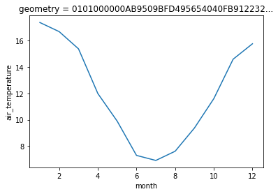

```python
Tair_monthly_means.plot()
```

#### Task 04

1. Regroup the ds_4years data into hours this time
2. Recalculate the mean, maximas, and standard deviations
3. Plot the results and lable figure appropriately